# Akbayan 2022 Data Strategy

Updated as of 22 February 2022

## Historical Context

The **Akbayan Citizens’ Action Party**, better known as **Akbayan**, is a social democratic and progressive political party in the Philippines. Akbayan is noted as a leading member of the progressive movement in the Philippines, having been formed in 1998 by a variety of progressive political organizations.

There are approximately 100 thousand members of Akbayan, with a pool of voter interest ranging anywhere between 150 thousand to 1 million people (at most 2.5% of Philippine active voters). (Source: [Akbayan’s Wikipedia page](https://en.wikipedia.org/wiki/Akbayan))

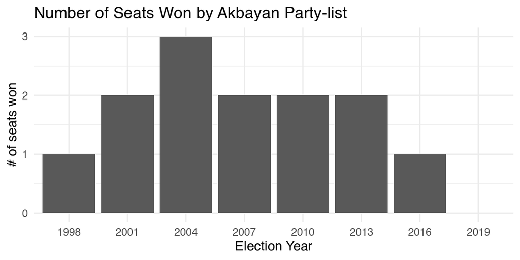

Prior to the 2019 elections, Akbayan had managed to win seats in all party list elections in the Philippines. Furthermore, Akbayan had previously surpassed a 2% share of party list votes in each of the elections from 1998 to 2013. In 2016, Akbayan fell short of the 2% threshold by just 0.12%.

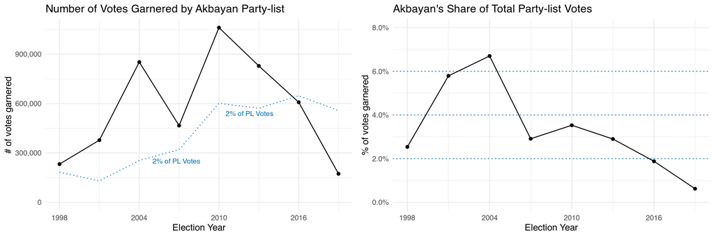

## Projecting Votes Needed to Win

### Assumptions from Past Data

| Variable | Notes | Assumption |
| --- | --- | --- |
| Total registered voters | From Official COMELEC Data | 65,745,529 |
| Actual voter turnout % | Using average since 2010 | 76.28% |
| Valid votes for PLs % | Using average since 2010 | 70.27% |

### Projections for the 2022 Elections

To project votes needed to secure 2 seats in the 2022 elections, we use the following formulas:

1. The estimated number of actual voters will be the number of registered voters multiplied by the expected voter turnout. We use official COMELEC data for the number of registered voters and the average turnout since 2010.
   $$ActualVotes_{2022} = RegVoters_{2022} \times Turnout_{ave} \\$$
2. The estimated number of valid votes cast for all party-lists will be the number of actual voters multiplied by the expected valid PL vote percentage. We use the average PL vote percentage from national elections since 2010.
   $$PLVotes_{2022} = ActualVotes_{2022} \times PLVotePercentage_{ave} \\$$
3. The estimated number of votes needed to secure at least 2 seats for a party-list will be the number of valid votes cast for all party-lists multiplied by 2%.
   $$TwoSeatMinVotes_{2022} = PLVotes_{2022} \times 2\% \\$$

In summary, we have:

| Variable | Formula | 2022 Projection |
| --- | --- | --- |
| Total actual voters | Total registered voters x Actual voter turnout % | 50,151,330 |
| Total valid PL votes | Actual voters x Valid PL vote % | 35,239,594 |
| Two percent of PL votes | Valid PL votes x 2% | 704,792 |

[figure not shown]

### Caveats and Limitations

- For now, we are ignoring competition between party-lists. Since the law guarantees at least 1 seat for party-lists that can clinch 2% of the vote, this threshold serves as a reasonable (and conservative) target.
- Garnering less than 2% of the vote still leaves a probability to win a seat (this is often the case). We might be able to predict a winning percentage less than 2% based on a party-list’s characteristics, i.e., total number of competitors, provincial-based vs sectoral, allied with current administration, allied with influential endorser, historical winning record, etc.
- Since we are using average turnout percentage and valid PL vote percentage from previous elections, there will be a margin for error. On one hand, a lower turnout rate and/or a lower PL vote rate will decrease the number of votes needed to clinch a seat; on the other hand, higher than average turnout and/or PL vote rates will raise the threshold number of votes.

## Targetting Local Votes

In order to target votes at the local level, we need to incorporate Akbayan’s past election performance in cities and municipalities into our national target. Since the 2019 election represented a steep decline in votes across nearly all areas, Akbayan’s 2013 and 2016 data may be much more instructive in targetting.

We use the following formula to estimate local targets:
$$Votes_{m, 2022} = \text{median}[Votes_{m, 2013}, \max(Votes_{m, 2016}, Vote_{m, 2019})]$$
where $Votes_{m, y}$ is the number of votes for the $m^{th}$ city/municipality during the year $y$ elections.

This formula implies that Akbayan would have to recover most of its past election performance to hit its target of securing 2% of the party-list votes.

### Regional Targets

|  | Region | Projected PL Votes | Target Votes for Akbayan | Share of PL Votes | Percent of National Target |
| --- | --- | --- | --- | --- | --- |
| 1 | National Capital Region (NCR) | 2721501 | 136190 | 0.0500422377210223 | 0.192249327007367 |
| 2 | Region IV-A (CALABARZON) | 3422186 | 116856 | 0.034146595187988 | 0.164956952469145 |
| 3 | Region III (Central Luzon) | 2915433 | 90184 | 0.0309333124787982 | 0.127306067309145 |
| 4 | Region VII (Central Visayas) | 2182666 | 70238 | 0.0321799120891607 | 0.099149777739507 |
| 5 | Region VI (Western Visayas) | 2076938 | 54134 | 0.0260643312414718 | 0.0764169547559793 |
| 6 | Region XIII (Caraga) | 786431 | 41706 | 0.0530319888203797 | 0.0588732684644193 |
| 7 | Region XI (Davao Region) | 1230497 | 26980 | 0.0219260997791949 | 0.0380856659274453 |
| 8 | Region XII (SOCCSKSARGEN) | 1041514 | 26832 | 0.0257624957513773 | 0.037876745298933 |
| 9 | Region I (Ilocos Region) | 1492825 | 22265 | 0.0149146751963559 | 0.0314298499582865 |
| 10 | Region V (Bicol Region) | 1610339 | 22064 | 0.0137014628596836 | 0.0311461131587529 |

[output cut: 7 more lines]

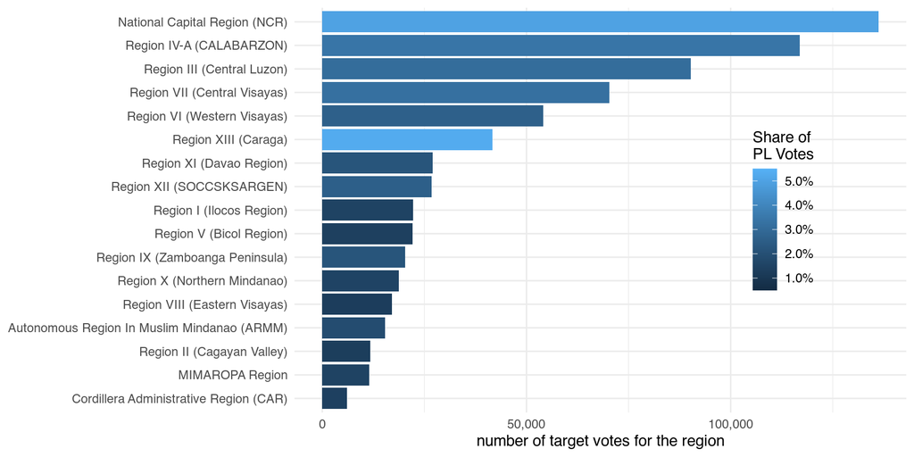

Notes:

- Regions with larger target votes constitute larger respective percentages of the national target. Logically, these are the vote-rich areas in NCR (19.2%), CALABRZON (16.5%), and Central Luzon (12.7%). Central (9.9%) and Western (7.6%) Visayas are also areas which make up a significant percentage of the overall target.
- Regions with *higher shares of PL votes* are those where Akbayan should have *relatively higher conversion rates*. These may not necessarily be regions with a large number of votes, but are regions which have in the past been more inclined to vote for Akbayan, relative to other areas. For example, Akbayan previously won and should win at least 5% of PL votes in Caraga and NCR; this is much higher than the overall average target of 2%. In essence, these regions should make up for areas where Akbayan fails to garner 2% of the PL votes.

### Provincial Targets

|  | Region | Province | Projected PL Votes | Target Votes for Akbayan | Share of PL Votes | Percent of National Target |
| --- | --- | --- | --- | --- | --- | --- |
| 1 | National Capital Region (NCR) | NCR, Second District (Not a Province) | 905682 | 47086 | 0.0519895504161505 | 0.0664678156360151 |
| 2 | National Capital Region (NCR) | NCR, Fourth District (Not a Province) | 834909 | 41952 | 0.0502473922307701 | 0.0592205284280276 |
| 3 | Region VII (Central Visayas) | Cebu | 1352967 | 39731 | 0.0293658308000121 | 0.0560853073744747 |
| 4 | Region IV-A (CALABARZON) | Laguna | 743550 | 29317 | 0.039428417725775 | 0.041384635581724 |
| 5 | National Capital Region (NCR) | NCR, Third District (Not a Province) | 573297 | 27834 | 0.0485507511813249 | 0.039291194418996 |
| 6 | Region IV-A (CALABARZON) | Cavite | 801989 | 26320 | 0.0328184052399721 | 0.0371539928543499 |
| 7 | Region IV-A (CALABARZON) | Rizal | 584467 | 26299 | 0.044996552414422 | 0.037124348711115 |
| 8 | Region III (Central Luzon) | Bulacan | 801657 | 24772 | 0.03090099631139 | 0.0349687960101806 |
| 9 | Region VI (Western Visayas) | Negros Occidental | 793821 | 22283 | 0.028070559987705 | 0.0314552592239163 |
| 10 | Region IV-A (CALABARZON) | Quezon | 555148 | 20483 | 0.0368964672483734 | 0.0289143326609289 |

[output cut: 77 more lines]

#### Notes:

- Similar observations are reflected at the provincial level. Vote-rich areas include NCR districts, Cebu, Laguna, Cavite, Rizal, Bulacan, Negros Occidental, and Quezon.
- High conversion areas include provinces such as Dinagat Islands, Siquijor, Agusan del Norte, Agusan del Sur, and Aurora.

### City and Municipal Targets

|  | Province | City/Municipality | Projected PL Votes | Target Votes for Akbayan | Share of PL Votes | Percent of National Target |
| --- | --- | --- | --- | --- | --- | --- |
| 1 | NCR, Second District (Not a Province) | Quezon City | 502715 | 25665 | 0.0510527833862129 | 0.0362293779105961 |
| 2 | NCR, City of Manila, First District (Not a Province) | City of Manila | 407613 | 19318 | 0.0473929928633287 | 0.0272697885243287 |
| 3 | NCR, Third District (Not a Province) | City of Caloocan | 264018 | 18671 | 0.0707186631214538 | 0.0263564665875215 |
| 4 | Cebu | City of Cebu (Capital) | 299008 | 13008 | 0.043503852739726 | 0.0183624292951893 |
| 5 | NCR, Fourth District (Not a Province) | City of Makati | 177644 | 11218 | 0.0631487694490104 | 0.0158356189908851 |
| 6 | NCR, Second District (Not a Province) | City of Pasig | 186473 | 10251 | 0.0549731060260735 | 0.0144705767762135 |
| 7 | Davao del Sur | City of Davao | 352277 | 8911 | 0.0252954351263352 | 0.0125789981126562 |
| 8 | Rizal | City of Antipolo (Capital) | 158451 | 8286 | 0.0522937690516311 | 0.0116967319449522 |
| 9 | NCR, Fourth District (Not a Province) | Pasay City | 109153 | 8234 | 0.075435398019294 | 0.0116233273997993 |
| 10 | Bulacan | City of San Jose Del Monte | 99335 | 7885 | 0.0793778627875371 | 0.0111306699717534 |

[output cut: 1624 more lines]